# Introducción

### ¡Bienvenidos!

Este documento es un [R Markdown](http://rmarkdown.rstudio.com) Notebook y será el formato en el que tendremos las notas de clase.

Vamos a arrancar descargando e instalando `R` siguiendo estas instrucciones:

1. Descargar R de la página web http://cran.r-project.org/.
2. Aquí pueden descargar `R` para Linux, Mac o Windows.
3. Una vez descargada la versión más actualizada del software, ejecute el instalador.

Después de que esté instalado `R`, continuamos con la instalación de `RStudio`, que es la interfraz gráfica que vamos a utilizar. Las instrucciones son:

1. Descargar RStudio de la página web https://www.rstudio.com/products/RStudio/.
2. Dar click en la pestaña *Products*,`RStudio`.
3. Descargar *RStudio Desktop*, Open Source Edition, que es la versión gratuita.

Una vez instalado `RStudio` vamos a instalar `R Markdown`, que es una librería que les permitirá crear documentos como este, donde pueden comentar de una manera más organizada los códigos que escriban. También pueden crear páginas web, dashboards, PDFs, documentos de Word, entre otros.

En la consola escriba:

```r
install.packages("rmarkdown")
```

```
Error in install.packages : Updating loaded packages
```

```r
library(rmarkdown)
```

En la página web http://rmarkdown.rstudio.com/gallery.html pueden encontrar ejemplos y templates de documentación realizada con `R Markdown.

### Obtener información de FRED Data

La Reserva Federal del Banco de St.Lois mantiene la base de datos pública llamada **FRED**, que contiene información de:

- Variables macroeconómicas: PIB, desempleo, oferta de dinero, ...
- Tasas de cambio
- Tasas de interés
- Precios de commodities
- Índices accionarios

Se puede descargar la información desde la página web https://fred.stlouisfed.org/ o directamente desde `R`, así:

```r
library(quantmod)
SP <- getSymbols("SP500",src="FRED", auto.assign=FALSE)
SP <- na.omit(SP)
```

Para saber si cargamos la información adecuada podemos ver algunas líneas de los datos.

**Del inicio:**

```r
head(SP,4)
```

```
             SP500
2011-07-27 1304.89
2011-07-28 1300.67
2011-07-29 1292.28
2011-08-01 1286.94
```

**Del final:**

```r
tail(SP,4)
```

```
             SP500
2021-07-21 4358.69
2021-07-22 4367.48
2021-07-23 4411.79
2021-07-26 4422.30
```

Ahora grafiquemos el índice:

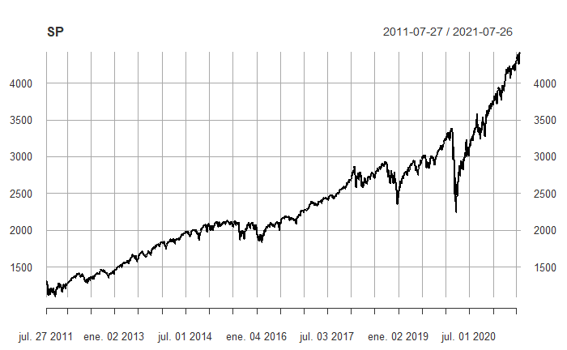

```r
plot(SP)
```

### Cálculo de los Retornos

El **retorno discreto** es igual a:

$ret_{t}=\frac{SP_{t}-SP_{t-1}}{SP_{t-1}}$

Mientras que el **retorno continuo** lo definimos como:

$logret_{t}=log(1+ret_{t})=log(SP_{t})-log(SP_{t-1})=log(\frac{SP_{t}}{SP_{t-1}})$

```r
logret <-diff(log(SP))
logret <-na.omit(logret)
head(logret,4)
```

```
                  SP500
2011-07-28 -0.003239230
2011-07-29 -0.006471416
2011-08-01 -0.004140793
2011-08-02 -0.025888994
```

**Gráfica de los retornos logarítmicos**

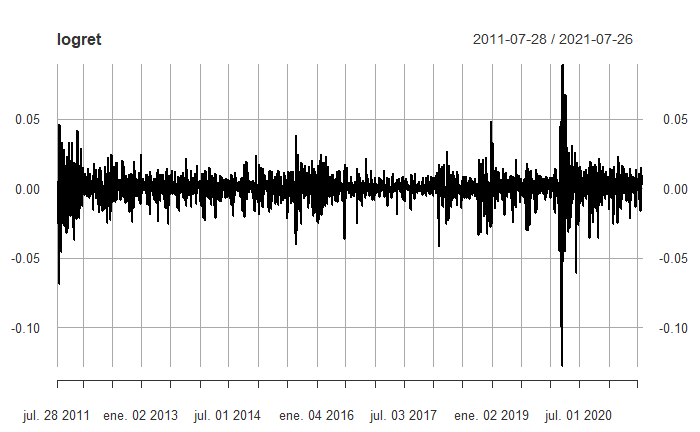

```r
plot(logret)
```

Si queremos pasar del retorno logarítmico al retorno discreto lo podemos hacer así: $ret_{t}=exp(logret_{t})-1$

```r
ret <-exp(logret)-1
head(ret,4)
```

```
                  SP500
2011-07-28 -0.003233989
2011-07-29 -0.006450522
2011-08-01 -0.004132231
2011-08-02 -0.025556747
```

#### **Pregunta:** ¿Qué tan parecidos son los retornos discretos con los logarítmicos? ¿Por qué preferimos los logarítmicos?

#### Horizontes de tiempo más largos

También podemos calcular los retornos para horizontes de tiempo diferentes al diario.

**De retorno logarítmico a 1-día a retorno logarítmico a n-días:**

**Estimación de los retornos semanales**

```r
logret_w <- apply.weekly(logret,sum)
head(logret_w,4)
```

```
                  SP500
2011-07-29 -0.009710646
2011-08-05 -0.074603344
2011-08-12 -0.017299302
2011-08-19 -0.048029940
```

`R` también tiene funciones para:

- Retornos mensuales: `apply.monthly`
- Retornos trimestrales: `apply.quarterly`
- Retornos anuales: `apply.yearly`

### Hechos Estilizados de los Retornos Financieros

**1. Baja autocorrelación de los retornos diarios**

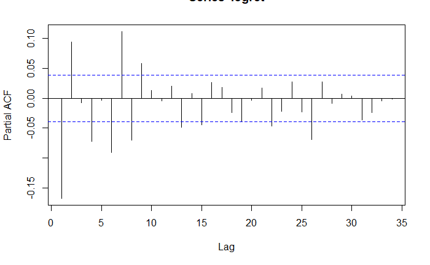

```r
pacf(logret)
```

**2. La distribución de los retornos no es normal**

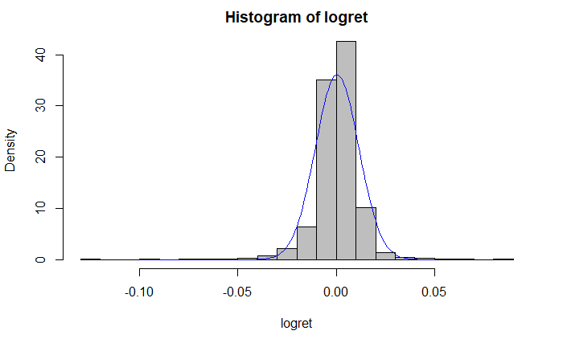

```r
hist(logret, freq=FALSE,breaks=20, col="gray")
lines(seq(-0.1,0.05, by=0.001), dnorm(seq(-0.1,0.05, by=0.001),
      mean(logret), sd(logret)), col="blue")
```

**3. Clusters de Volatilidad**

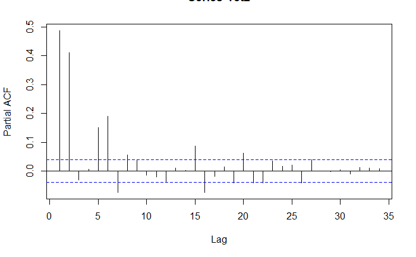

```r
ret2 = logret^2
pacf(ret2)
```